# Effects of Transmission Type on Miles per Gallon

Toby Popenfoose

June 20, 2015

### Exploratory Data Analysis:

There were no missing values found.

For EDA I used the str, summary, cor and table functions. See the roughDraft report on github for the particulars.

```r
str(mtcars)
```

```
## 'data.frame':    32 obs. of  11 variables:
##  $ mpg : num  21 21 22.8 21.4 18.7 18.1 14.3 24.4 22.8 19.2 ...
##  $ cyl : num  6 6 4 6 8 6 8 4 4 6 ...
##  $ disp: num  160 160 108 258 360 ...
##  $ hp  : num  110 110 93 110 175 105 245 62 95 123 ...
##  $ drat: num  3.9 3.9 3.85 3.08 3.15 2.76 3.21 3.69 3.92 3.92 ...
##  $ wt  : num  2.62 2.88 2.32 3.21 3.44 ...
##  $ qsec: num  16.5 17 18.6 19.4 17 ...
##  $ vs  : num  0 0 1 1 0 1 0 1 1 1 ...
##  $ am  : num  1 1 1 0 0 0 0 0 0 0 ...
##  $ gear: num  4 4 4 3 3 3 3 4 4 4 ...
##  $ carb: num  4 4 1 1 2 1 4 2 2 4 ...
```

```r
summary(mtcars)
```

```
##       mpg            cyl            disp             hp
##  Min.   :10.4   Min.   :4.00   Min.   : 71.1   Min.   : 52.0
##  1st Qu.:15.4   1st Qu.:4.00   1st Qu.:120.8   1st Qu.: 96.5
##  Median :19.2   Median :6.00   Median :196.3   Median :123.0
##  Mean   :20.1   Mean   :6.19   Mean   :230.7   Mean   :146.7
##  3rd Qu.:22.8   3rd Qu.:8.00   3rd Qu.:326.0   3rd Qu.:180.0
##  Max.   :33.9   Max.   :8.00   Max.   :472.0   Max.   :335.0
##       drat            wt            qsec            vs
##  Min.   :2.76   Min.   :1.51   Min.   :14.5   Min.   :0.000
##  1st Qu.:3.08   1st Qu.:2.58   1st Qu.:16.9   1st Qu.:0.000
##  Median :3.69   Median :3.33   Median :17.7   Median :0.000
##  Mean   :3.60   Mean   :3.22   Mean   :17.8   Mean   :0.438
##  3rd Qu.:3.92   3rd Qu.:3.61   3rd Qu.:18.9   3rd Qu.:1.000
##  Max.   :4.93   Max.   :5.42   Max.   :22.9   Max.   :1.000
##        am             gear           carb
##  Min.   :0.000   Min.   :3.00   Min.   :1.00
##  1st Qu.:0.000   1st Qu.:3.00   1st Qu.:2.00
##  Median :0.000   Median :4.00   Median :2.00
##  Mean   :0.406   Mean   :3.69   Mean   :2.81
##  3rd Qu.:1.000   3rd Qu.:4.00   3rd Qu.:4.00
##  Max.   :1.000   Max.   :5.00   Max.   :8.00
```

```r
cor(mtcars)
```

```
##          mpg     cyl    disp      hp     drat      wt    qsec      vs
## mpg   1.0000 -0.8522 -0.8476 -0.7762  0.68117 -0.8677  0.4187  0.6640
## cyl  -0.8522  1.0000  0.9020  0.8324 -0.69994  0.7825 -0.5912 -0.8108
## disp -0.8476  0.9020  1.0000  0.7909 -0.71021  0.8880 -0.4337 -0.7104
## hp   -0.7762  0.8324  0.7909  1.0000 -0.44876  0.6587 -0.7082 -0.7231
## drat  0.6812 -0.6999 -0.7102 -0.4488  1.00000 -0.7124  0.0912  0.4403
## wt   -0.8677  0.7825  0.8880  0.6587 -0.71244  1.0000 -0.1747 -0.5549
## qsec  0.4187 -0.5912 -0.4337 -0.7082  0.09120 -0.1747  1.0000  0.7445
## vs    0.6640 -0.8108 -0.7104 -0.7231  0.44028 -0.5549  0.7445  1.0000
## am    0.5998 -0.5226 -0.5912 -0.2432  0.71271 -0.6925 -0.2299  0.1683
## gear  0.4803 -0.4927 -0.5556 -0.1257  0.69961 -0.5833 -0.2127  0.2060
## carb -0.5509  0.5270  0.3950  0.7498 -0.09079  0.4276 -0.6562 -0.5696
##            am    gear     carb
## mpg   0.59983  0.4803 -0.55093
## cyl  -0.52261 -0.4927  0.52699
## disp -0.59123 -0.5556  0.39498
## hp   -0.24320 -0.1257  0.74981
## drat  0.71271  0.6996 -0.09079
## wt   -0.69250 -0.5833  0.42761
## qsec -0.22986 -0.2127 -0.65625
## vs    0.16835  0.2060 -0.56961
## am    1.00000  0.7941  0.05753
## gear  0.79406  1.0000  0.27407
## carb  0.05753  0.2741  1.00000
```

```r
table(mtcars$am)
```

```
##
##  0  1
## 19 13
```

It appears that two variables, am and vs, do not make sense as numeric. I will transform am and vs to factors so the modeling functions will behave better.

```r
mtcars$am <- factor(mtcars$am)
mtcars$vs <- factor(mtcars$vs)
```

### Simple Linear Model:

A naive starting point would be to just do a simple linear regression of just the independent variable am to predict mpg. After doing a simple linear model with just ‘am’ for the predictor, only 36% of the variation is explained by the model suggesting there are other confounder variables to be accounted for.

```r
fit1 <- lm(mpg ~ am, mtcars)
confint(fit1, level=.95)  # 95% confidence interval
```

```
##              2.5 % 97.5 %
## (Intercept) 14.851  19.44
## am1          3.642  10.85
```

```r
summary(fit1)
```

```
##
## Call:
## lm(formula = mpg ~ am, data = mtcars)
##
## Residuals:
##    Min     1Q Median     3Q    Max
## -9.392 -3.092 -0.297  3.244  9.508
##
## Coefficients:
##             Estimate Std. Error t value Pr(>|t|)
## (Intercept)    17.15       1.12   15.25  1.1e-15
## am1             7.24       1.76    4.11  0.00029
##
## Residual standard error: 4.9 on 30 degrees of freedom
## Multiple R-squared:  0.36,   Adjusted R-squared:  0.338
## F-statistic: 16.9 on 1 and 30 DF,  p-value: 0.000285
```

```r
tidy(fit1, conf.int=TRUE)
```

```
##          term estimate std.error statistic   p.value conf.low conf.high
## 1 (Intercept)   17.147     1.125    15.247 1.134e-15   14.851     19.44
## 2         am1    7.245     1.764     4.106 2.850e-04    3.642     10.85
```

```r
glance(fit1)
```

```
##   r.squared adj.r.squared sigma statistic  p.value df logLik   AIC   BIC
## 1    0.3598        0.3385 4.902     16.86 0.000285  2 -95.24 196.5 200.9
##   deviance df.residual
## 1    720.9          30
```

```r
augment(fit1)
```

```
##              .rownames  mpg am .fitted .se.fit  .resid    .hat .sigma
## 1            Mazda RX4 21.0  1   24.39   1.360 -3.3923 0.07692  4.943
## 2        Mazda RX4 Wag 21.0  1   24.39   1.360 -3.3923 0.07692  4.943
## 3           Datsun 710 22.8  1   24.39   1.360 -1.5923 0.07692  4.976
## 4       Hornet 4 Drive 21.4  0   17.15   1.125  4.2526 0.05263  4.919
## 5    Hornet Sportabout 18.7  0   17.15   1.125  1.5526 0.05263  4.977
## 6              Valiant 18.1  0   17.15   1.125  0.9526 0.05263  4.983
## 7           Duster 360 14.3  0   17.15   1.125 -2.8474 0.05263  4.956
## 8            Merc 240D 24.4  0   17.15   1.125  7.2526 0.05263  4.790
## 9             Merc 230 22.8  0   17.15   1.125  5.6526 0.05263  4.868
## 10            Merc 280 19.2  0   17.15   1.125  2.0526 0.05263  4.970
## 11           Merc 280C 17.8  0   17.15   1.125  0.6526 0.05263  4.984
## 12          Merc 450SE 16.4  0   17.15   1.125 -0.7474 0.05263  4.984
## 13          Merc 450SL 17.3  0   17.15   1.125  0.1526 0.05263  4.986
## 14         Merc 450SLC 15.2  0   17.15   1.125 -1.9474 0.05263  4.972
```

[output cut: 51 more lines]

### Multivariate Linear Model:

With 10 possible predictor variables there are 2^10= 1,024 different models. To save time, I used stepFit and regsubsets from the leaps package for variable selection using AIC in stepFit and BIC in leaps. See Figures 4 and 5 for graphs of the results. Based on the multiple models both methods tested, I have chose to use additional variables of weight and quarter mile time. Using transmission type, weight and quarter mile time explains 85% of the variance.

```r
leapsFit <- regsubsets(mpg ~ ., data=mtcars, nvmax=8)
leapsSummary <- summary(leapsFit); leapsSummary
```

```
## Subset selection object
## Call: regsubsets.formula(mpg ~ ., data = mtcars, nvmax = 8)
## 10 Variables  (and intercept)
##      Forced in Forced out
## cyl      FALSE      FALSE
## disp     FALSE      FALSE
## hp       FALSE      FALSE
## drat     FALSE      FALSE
## wt       FALSE      FALSE
## qsec     FALSE      FALSE
## vs1      FALSE      FALSE
## am1      FALSE      FALSE
## gear     FALSE      FALSE
## carb     FALSE      FALSE
## 1 subsets of each size up to 8
## Selection Algorithm: exhaustive
##          cyl disp hp  drat wt  qsec vs1 am1 gear carb
## 1  ( 1 ) " " " "  " " " "  "*" " "  " " " " " "  " "
## 2  ( 1 ) "*" " "  " " " "  "*" " "  " " " " " "  " "
## 3  ( 1 ) " " " "  " " " "  "*" "*"  " " "*" " "  " "
## 4  ( 1 ) " " " "  "*" " "  "*" "*"  " " "*" " "  " "
## 5  ( 1 ) " " "*"  "*" " "  "*" "*"  " " "*" " "  " "
## 6  ( 1 ) " " "*"  "*" "*"  "*" "*"  " " "*" " "  " "
## 7  ( 1 ) " " "*"  "*" "*"  "*" "*"  " " "*" "*"  " "
## 8  ( 1 ) " " "*"  "*" "*"  "*" "*"  " " "*" "*"  "*"
```

```r
names(leapsSummary)
```

```
## [1] "which"  "rsq"    "rss"    "adjr2"  "cp"     "bic"    "outmat" "obj"
```

```r
leapsSummary$rsq
```

```
## [1] 0.7528 0.8302 0.8497 0.8579 0.8637 0.8667 0.8681 0.8687
```

```r
coef(leapsFit, 3)
```

```
## (Intercept)          wt        qsec         am1
##       9.618      -3.917       1.226       2.936
```

```r
stepFit <- step(lm(mpg ~ ., data=mtcars))
```

```
## Start:  AIC=70.9
## mpg ~ cyl + disp + hp + drat + wt + qsec + vs + am + gear + carb
##
##        Df Sum of Sq RSS  AIC
## - cyl   1      0.08 148 68.9
## - vs    1      0.16 148 68.9
## - carb  1      0.41 148 69.0
## - gear  1      1.35 149 69.2
## - drat  1      1.63 149 69.2
## - disp  1      3.92 151 69.7
## - hp    1      6.84 154 70.3
## - qsec  1      8.86 156 70.8
## <none>              148 70.9
## - am    1     10.55 158 71.1
## - wt    1     27.01 174 74.3
##
## Step:  AIC=68.92
## mpg ~ disp + hp + drat + wt + qsec + vs + am + gear + carb
##
##        Df Sum of Sq RSS  AIC
## - vs    1      0.27 148 67.0
## - carb  1      0.52 148 67.0
## - gear  1      1.82 149 67.3
## - drat  1      1.98 150 67.3
## - disp  1      3.90 152 67.7
## - hp    1      7.36 155 68.5
## <none>              148 68.9
## - qsec  1     10.09 158 69.0
## - am    1     11.84 159 69.4
## - wt    1     27.03 175 72.3
##
## Step:  AIC=66.97
## mpg ~ disp + hp + drat + wt + qsec + am + gear + carb
##
##        Df Sum of Sq RSS  AIC
## - carb  1      0.69 148 65.1
## - gear  1      2.14 150 65.4
## - drat  1      2.21 150 65.4
## - disp  1      3.65 152 65.8
## - hp    1      7.11 155 66.5
```

[output cut: 44 more lines]

```
##        Df Sum of Sq RSS  AIC
## - hp    1       9.2 169 61.3
## <none>              160 61.5
## - qsec  1      20.2 180 63.3
## - am    1      26.0 186 64.3
## - wt    1      78.5 239 72.3
##
## Step:  AIC=61.31
## mpg ~ wt + qsec + am
##
##        Df Sum of Sq RSS  AIC
## <none>              169 61.3
## - am    1      26.2 195 63.9
## - qsec  1     109.0 278 75.2
## - wt    1     183.3 353 82.8
```

```r
summary(stepFit)
```

```
##
## Call:
## lm(formula = mpg ~ wt + qsec + am, data = mtcars)
##
## Residuals:
##    Min     1Q Median     3Q    Max
## -3.481 -1.556 -0.726  1.411  4.661
##
## Coefficients:
##             Estimate Std. Error t value Pr(>|t|)
## (Intercept)    9.618      6.960    1.38  0.17792
## wt            -3.917      0.711   -5.51 0.000007
## qsec           1.226      0.289    4.25  0.00022
## am1            2.936      1.411    2.08  0.04672
##
## Residual standard error: 2.46 on 28 degrees of freedom
## Multiple R-squared:  0.85,   Adjusted R-squared:  0.834
## F-statistic: 52.7 on 3 and 28 DF,  p-value: 0.0000000000121
```

```r
finalFit <- lm(mpg ~ am + wt + qsec, data=mtcars)
confint(finalFit, level=.95)  # 95% confidence interval
```

```
##                2.5 % 97.5 %
## (Intercept) -4.63830 23.874
## am1          0.04573  5.826
## wt          -5.37333 -2.460
## qsec         0.63457  1.817
```

```r
summary(finalFit)
```

```
##
## Call:
## lm(formula = mpg ~ am + wt + qsec, data = mtcars)
##
## Residuals:
##    Min     1Q Median     3Q    Max
## -3.481 -1.556 -0.726  1.411  4.661
##
## Coefficients:
##             Estimate Std. Error t value Pr(>|t|)
## (Intercept)    9.618      6.960    1.38  0.17792
## am1            2.936      1.411    2.08  0.04672
## wt            -3.917      0.711   -5.51 0.000007
## qsec           1.226      0.289    4.25  0.00022
##
## Residual standard error: 2.46 on 28 degrees of freedom
## Multiple R-squared:  0.85,   Adjusted R-squared:  0.834
## F-statistic: 52.7 on 3 and 28 DF,  p-value: 0.0000000000121
```

```r
tidy(finalFit, conf.int=TRUE)
```

```
##          term estimate std.error statistic     p.value conf.low conf.high
## 1 (Intercept)    9.618    6.9596     1.382 0.177915165 -4.63830    23.874
## 2         am1    2.936    1.4109     2.081 0.046715510  0.04573     5.826
## 3          wt   -3.917    0.7112    -5.507 0.000006953 -5.37333    -2.460
## 4        qsec    1.226    0.2887     4.247 0.000216174  0.63457     1.817
```

```r
glance(finalFit)
```

```
##   r.squared adj.r.squared sigma statistic         p.value df logLik   AIC
## 1    0.8497        0.8336 2.459     52.75 0.0000000000121  4 -72.06 154.1
##     BIC deviance df.residual
## 1 161.4    169.3          28
```

```r
augment(finalFit)
```

```
##              .rownames  mpg am    wt  qsec .fitted .se.fit  .resid    .hat
## 1            Mazda RX4 21.0  1 2.620 16.46   22.47  0.7197 -1.4705 0.08567
## 2        Mazda RX4 Wag 21.0  1 2.875 17.02   22.16  0.7435 -1.1582 0.09143
## 3           Datsun 710 22.8  1 2.320 18.61   26.28  0.7598 -3.4811 0.09548
## 4       Hornet 4 Drive 21.4  0 3.215 19.44   20.86  0.6849  0.5426 0.07759
## 5    Hornet Sportabout 18.7  0 3.440 17.02   17.01  0.7486  1.6904 0.09268
## 6              Valiant 18.1  0 3.460 20.22   20.85  0.7677 -2.7541 0.09747
## 7           Duster 360 14.3  0 3.570 15.84   15.05  0.9417 -0.7539 0.14667
## 8            Merc 240D 24.4  0 3.190 20.00   21.64  0.7466  2.7581 0.09219
## 9             Merc 230 22.8  0 3.150 22.90   25.35  1.3401 -2.5536 0.29704
## 10            Merc 280 19.2  0 3.440 18.30   18.58  0.6054  0.6213 0.06063
## 11           Merc 280C 17.8  0 3.440 18.90   19.31  0.6080 -1.5143 0.06115
## 12          Merc 450SE 16.4  0 4.070 17.40   15.01  0.6076  1.3920 0.06105
## 13          Merc 450SL 17.3  0 3.730 17.60   16.58  0.5931  0.7152 0.05818
## 14         Merc 450SLC 15.2  0 3.780 18.00   16.88  0.5663 -1.6793 0.05304
```

[output cut: 51 more lines]

### Diagnostics and Inference:

```r
anova(fit1, finalFit)
```

```
## Analysis of Variance Table
##
## Model 1: mpg ~ am
## Model 2: mpg ~ am + wt + qsec
##   Res.Df RSS Df Sum of Sq    F       Pr(>F)
## 1     30 721
## 2     28 169  2       552 45.6 0.0000000016
```

The results of the anova are statistically significant at the 95% level and suggests that the multivariable model is better by looking at the residual sum of squares.

```r
vif(finalFit)
```

```
##    am    wt  qsec
## 2.541 2.483 1.364
```

The variance inflation factor suggests there is only moderate correlation between the variables selected which suggests there is not a large amount of collinearity between the variables.

```r
PRESS(fit1)
```

```
## [1] 830.3
```

```r
PRESS(finalFit)
```

```
## [1] 231.3
```

The PRESS statistic is less for the multivariable linear model which suggest is has higher predictive ability due to less predictive error than the simple linear model.

### Appendix:

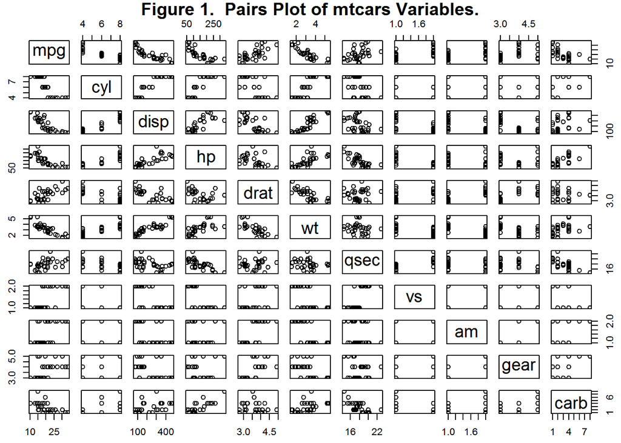

```r
pairs(mtcars, main = "Figure 1.  Pairs Plot of mtcars Variables.", line.main=1.5, oma=c(2,2,3,2))
```

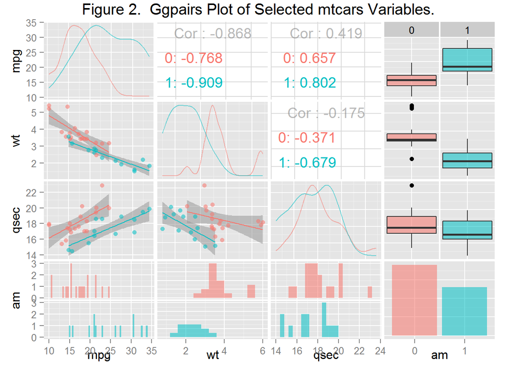

```r
ggpairs(mtcars[ ,c(1,6,7,9)], lower=list(continuous="smooth"), colour="am", alpha=0.4,
        params = c(binwidth=.4), title="Figure 2.  Ggpairs Plot of Selected mtcars Variables.")
```

Figure 3. Residuals and Diagnostics Plots for Simple Linear Model.

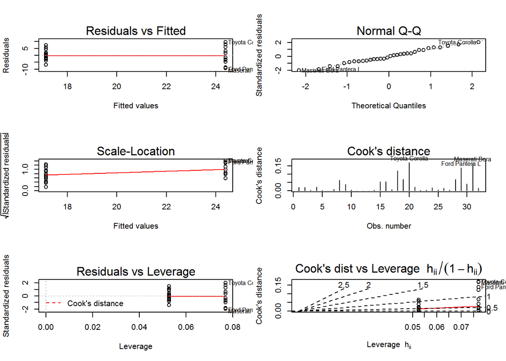

```r
par(mfrow=c(3,2)); plot(fit1, which=1:6)
```

Figure 4. Multivariate Variable Selection.

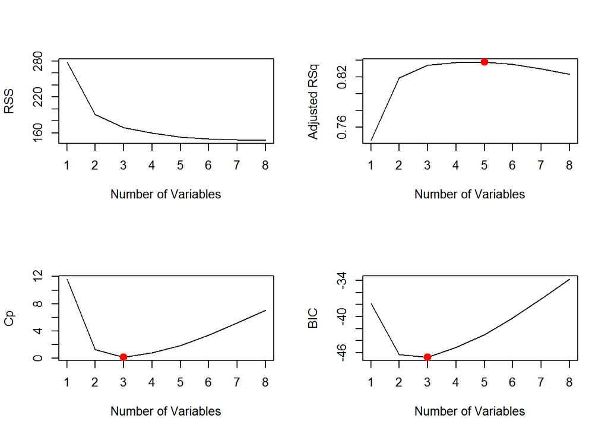

```r
par(mfrow=c(2,2))
plot(leapsSummary$rss, xlab="Number of Variables", ylab="RSS", type="l")
plot(leapsSummary$adjr2, xlab="Number of Variables", ylab="Adjusted RSq", type="l")
points(which.max(leapsSummary$adjr2),
       leapsSummary$adjr2[which.max(leapsSummary$adjr2)], col="red", cex=2, pch=20)
plot(leapsSummary$cp,xlab="Number of Variables", ylab="Cp", type="l")
points(which.min(leapsSummary$cp), leapsSummary$cp[which.min(leapsSummary$cp)],
       col="red", cex=2, pch=20)
plot(leapsSummary$bic, xlab="Number of Variables", ylab="BIC", type="l")
points(which.min(leapsSummary$bic), leapsSummary$bic[which.min(leapsSummary$bic)],
       col="red", cex=2, pch=20)
```

Figure 5. Multivariate Variables.

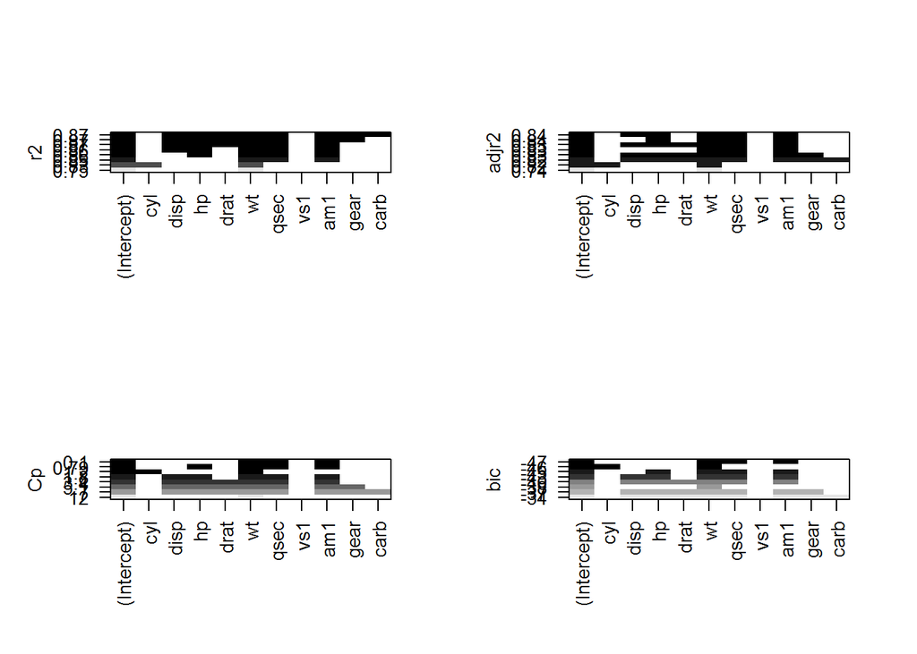

```r
par(mfrow=c(2,2))
plot(leapsFit, scale="r2")
plot(leapsFit, scale="adjr2")
plot(leapsFit, scale="Cp")
plot(leapsFit, scale="bic")
```

Figure 6. Residuals and Diagnostics Plots for Final Multivariable Linear Model.

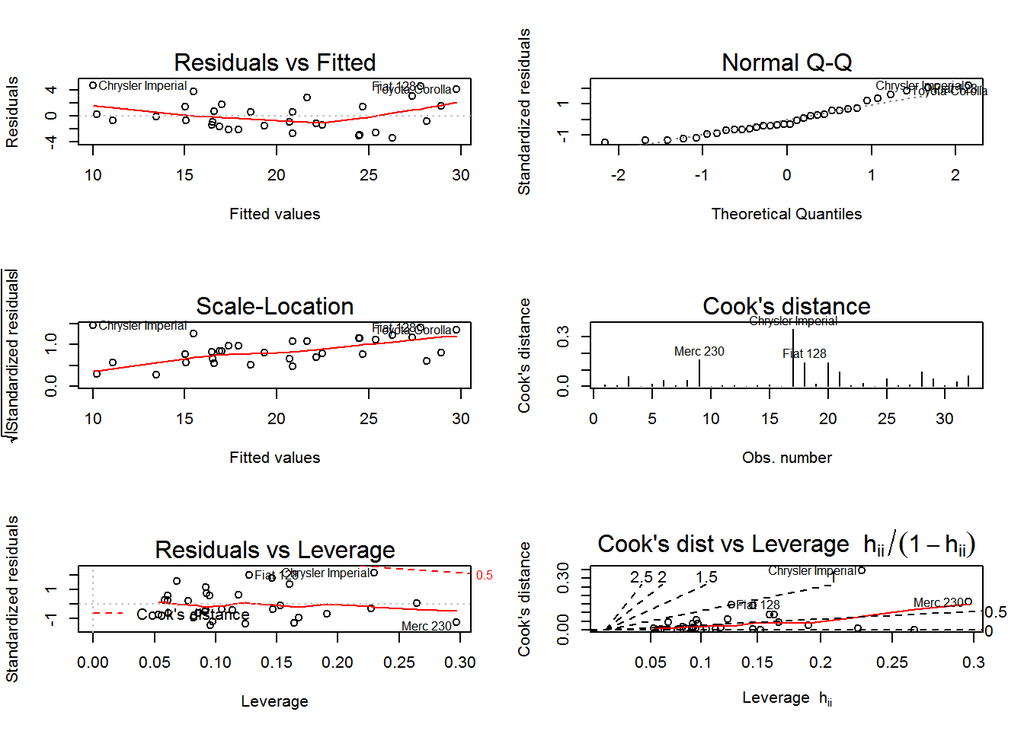

```r
par(mfrow=c(3,2)); plot(finalFit, which=1:6)
```